# Final Project

Emily Arbieto

2025-04-19

## Introduction

Hello, My name is Emily Arbieto and I am a 3rd Year Statistics Major studying at the university of Virginia. Additionally, I am pursuing a political science minor, where we focus on regime type and several influencing factors like economic condition, backsliding, corruption, literacy, etc. One of the more difficult topics of Political Science is that we usually run into the problem of causality- we can’t usually figure out if many factors cause another when it comes to regime type, and so today I wanted to focus on geography. This project explores how geographic and political factors shape the distribution and dimensions of freedom around the world. Through a series of interactive and static visualizations, we examine how population, landlocked status, regime type, and region relate to measures of political rights, civil liberties, and rule of law. I aim to challenge assumptions about geography as destiny and highlight the uneven progress of freedom globally.

## Visualization 1

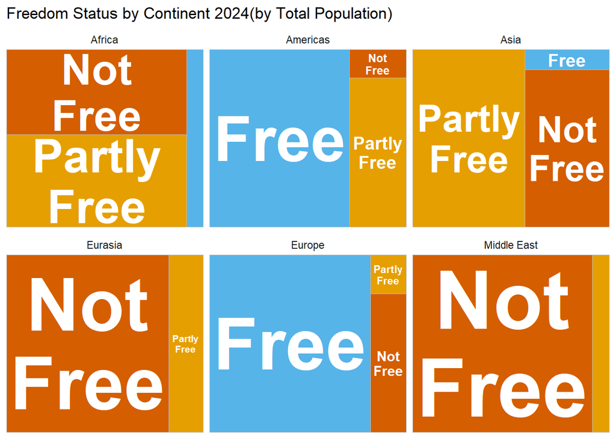

This tree map illustrates the global distribution of freedom across different continents, highlighting significant regional disparities. Much of the world is still “not free.” Notably, Africa and the Middle East are marked by a larger proportion of Not Free countries, reflecting the challenges these regions face in establishing and maintaining democratic systems. In contrast, Europe and the Americas show a predominance of Free nations, underscoring the political stability and democratic governance in these areas. By using population size as a basis for the area of each section, the tree map allows viewers to visually grasp how freedom status is distributed relative to global populations. The clear color coding and simple design principles of this visualization make it an accessible tool for exploring the intersection of geography and regime type, reinforcing the idea that political freedom is not uniform across the globe and challenging assumptions about geography determining a nation’s political future.

## Visualization 2

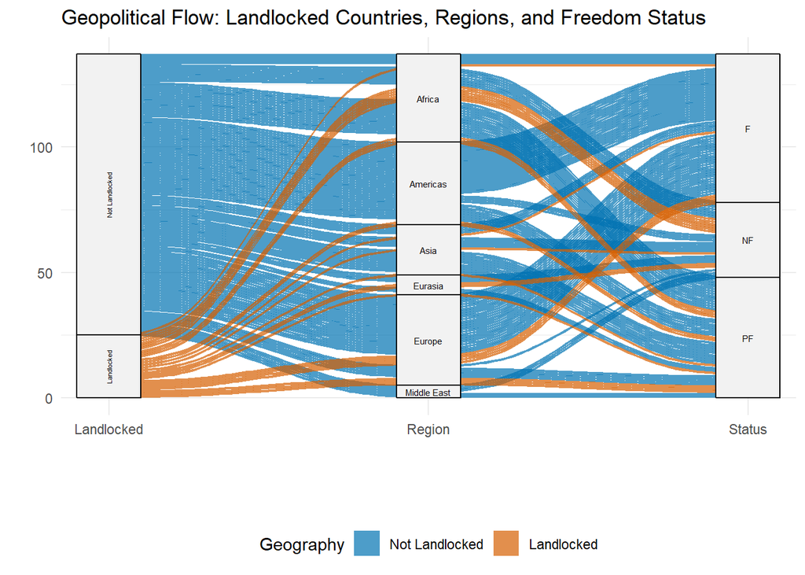

In this 2nd visualization, we explore to see if another aspect of geography, being landlocked, has any effect on regime. It challenges the assumption that geography alone dictates a country’s political trajectory. The lines linking landlocked countries don’t all point to being not free, although there are very few countries that are actually free. Conversely, Not Landlocked countries (represented in blue) are more likely to be Free (F), suggesting that access to the sea and international trade may contribute to more favorable political and economic conditions condusive to democracy. A small thing to note is that the Middle east, as seen in the previous visualization, has no free countries, as well as having no landlocked countries. This also suggests that there could be larger factors at play, as the middle east has historically been a hot spot for armed conflict, oil exports (economic disparities), religious influence- much of which is hard to pinpoint for causality.

## Visualization 3

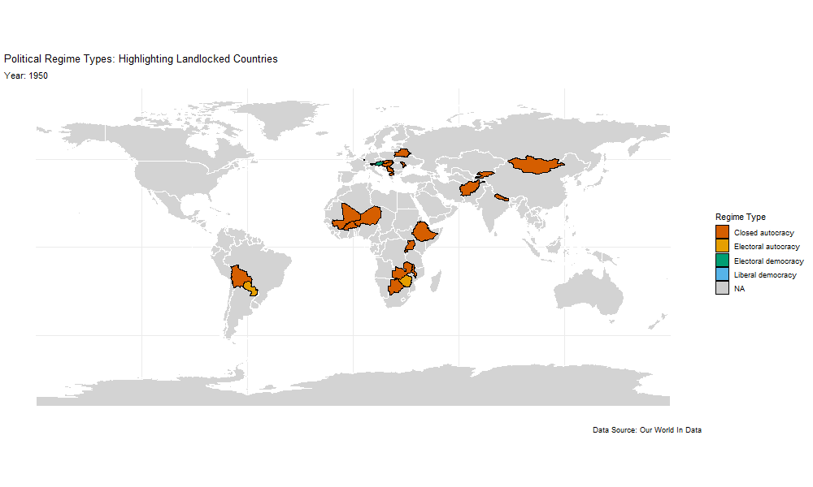

Eurasia and Asia also have significant portions of landlocked countries, with some of them categorized as Partly Free (PF), which might reflect the transitional nature of governance in these regions. Though there is actually a spectacle- Mongolia was able to transition despite being in between 2 world superpowers known for being an authoritarian/not free regime. Mongolia had been a Soviet satellite state for much of the 20th century, aligning itself closely with the Soviet Union politically, economically, and militarily. In the late 1980s, it transitioned (abruptly) into an Electoral democracy. This followed the collapse of the Soviet Union.

The landlocked countries in Europe present an interesting case when examining the evolution of political regimes over time. Unlike many landlocked countries in the other regions, the landlocked nations of Europe have generally followed a path toward democracy and stability, especially past the World War 2 Era. The geopolitical environment in Europe plays a major role in shaping the political stability of landlocked nations. Many European countries, including landlocked ones, are part of the European Union (EU), which promotes democratic values, rule of law, and human rights. The presence of neighboring liberal democracies and the economic and political stability provided by the EU has allowed landlocked European nations to thrive democratically.

## Visualization 4

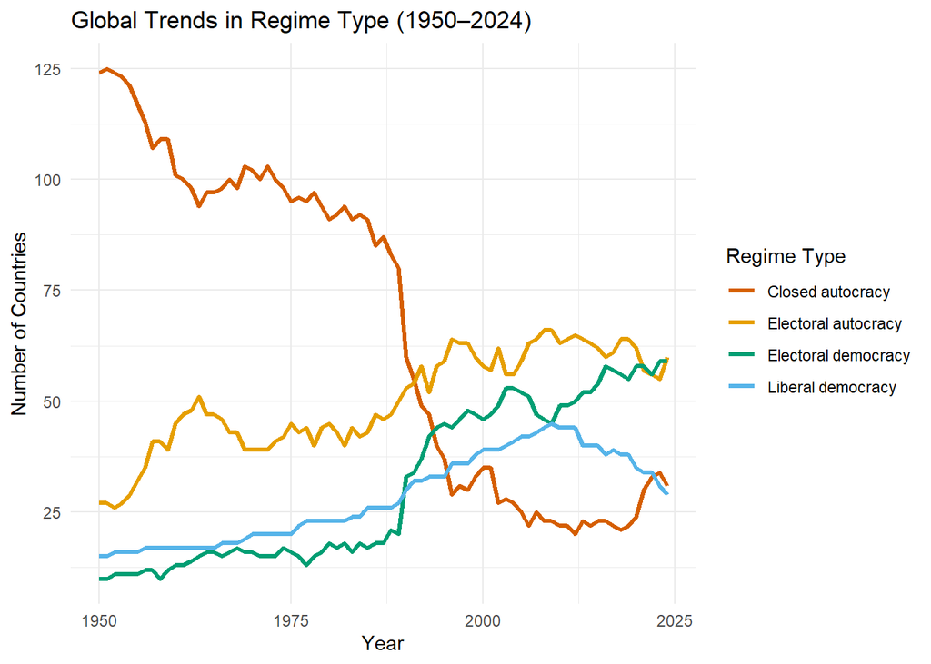

## Visualization 5

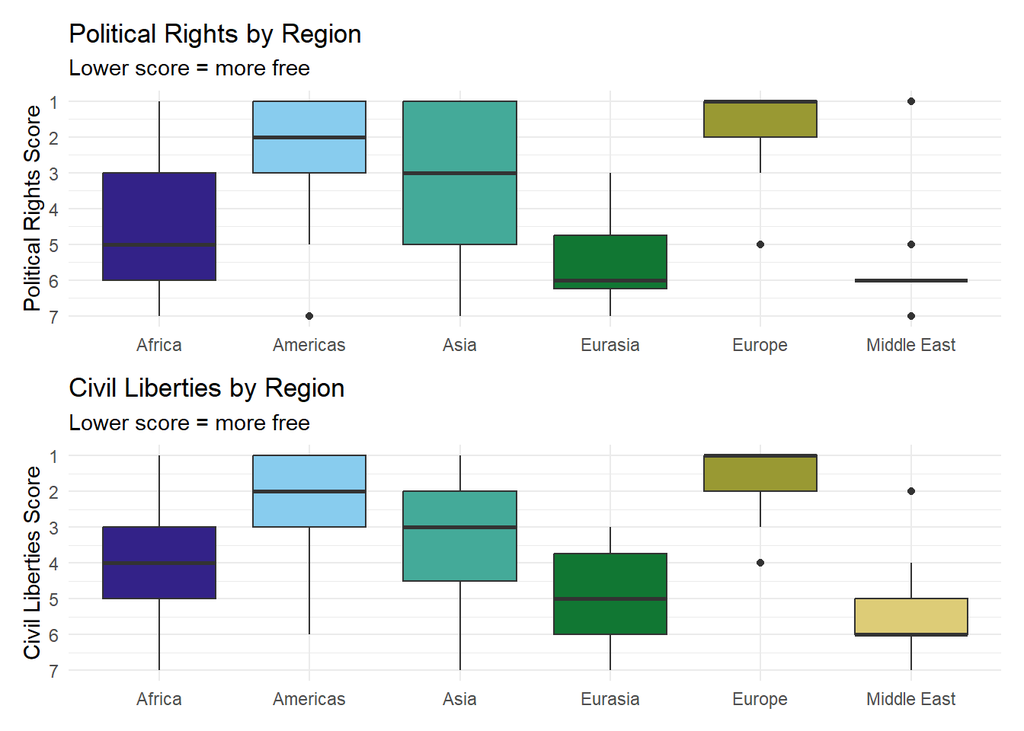

## Visualization 6

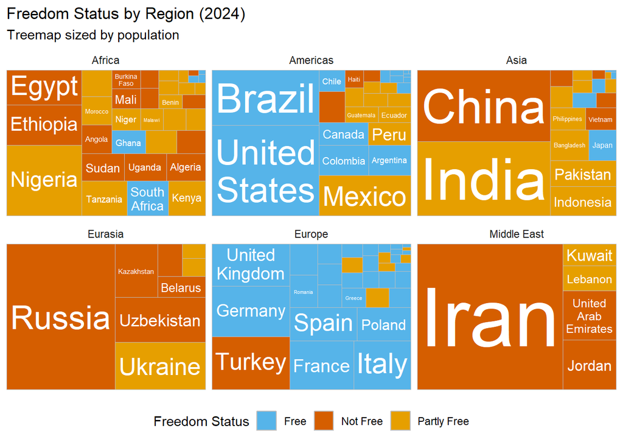

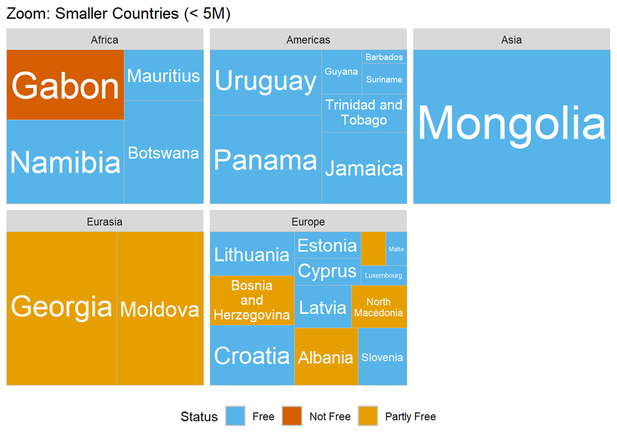

In this visualization, I wanted to explore the relationship between population across different continents and Freedom- are most countries of similar population within continents of the same status? The largest countries in terms of population, such as China, India, and United States, are visually prominent. China and India, despite their large populations, are shown with a larger portion of the country marked as Not Free (NF) or Partly Free (PF), highlighting how even populous countries can struggle with democratic freedoms- which is against the general assumption that democracy would flourish in larger spaces. China is particularly notable for being a closed autocracy, despite its massive population. Russia, China, and the United States are all notably large Countries, though they have such different outcomes. In the zoomed-in view of smaller countries, we can observe that even among smaller nations (those with populations under 5 million), there is significant variation in freedom status. For example, countries like Panama, Uruguay, and Mongolia show up as Free (F), with larger blue boxes, indicating that even small nations can have stable democratic systems. Maybe this would suggest that population is actually a stronger indicator at the micro level, though on the larger scale, most continents have a consistent pattern, where most of 1 continent will have a consistent regime. This visualization also furthers a question of population density, and if there is a relationship with regime.

## Visualization 7

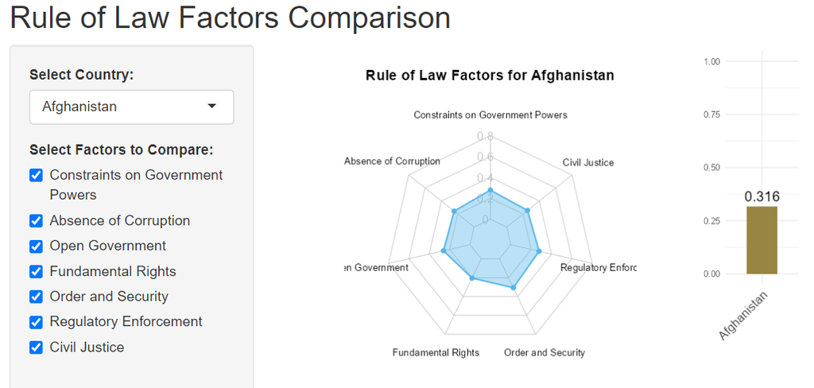

https://emmiya.shinyapps.io/STATFINALPROJ/

This Shiny app visualization could be used to explore how rule of law factors intersect with a country’s freedom status, providing deeper insight into the underlying conditions that contribute to a country’s political trajectory. The radar chart highlights critical factors such as corruption, government accountability, and civil justice, which are key to understanding whether a country leans towards authoritarianism or democracy. Much of these factors are key in influencing democratic backsliding, predicting when a country may go into a different regime. By comparing these factors with the freedom status data in the tree maps and box plots, we can examine how governance issues like lack of accountability and weak legal frameworks often correlate with low freedom scores. For instance, regions or countries that perform poorly on civil justice or regulatory enforcement may also show high proportions of Not Free (NF) nations, reflecting how poor governance can lead to restricted political rights and civil liberties. This app adds a layer of granular analysis to the broader trends in regime type and freedom status, helping to illustrate that geopolitical influences, corruption, and governance are major factors in determining political freedoms, beyond just geographic location or population size.

## Visualization 8

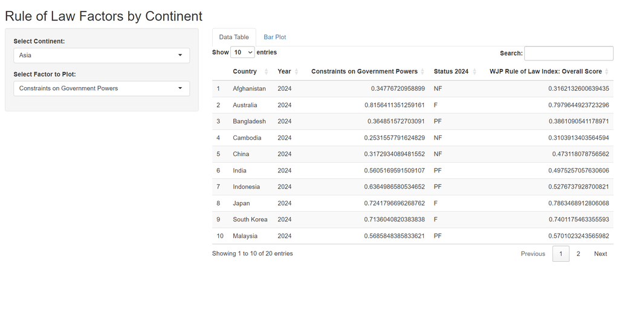

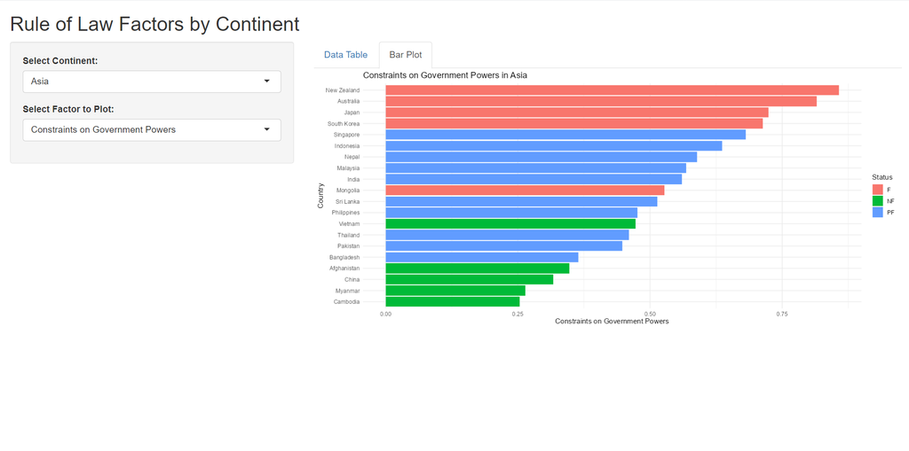

https://emmiya.shinyapps.io/STATFINALPROJ2/

## Conclusion

This series of visualizations collectively underscore the complex relationship between geography, regime type, and freedom status. While geography plays a role in shaping political environments, the data clearly illustrates that regime type is not solely determined by a country’s location or population size. The treemaps and alluvial diagrams reveal that countries across different continents, regardless of their geographic proximity, can exhibit a wide range of political regimes—from democratic to authoritarian—challenging the assumption that geographic factors alone predict political freedom.

For instance, landlocked countries like Switzerland and Botswana can experience democratic governance, while others like Mali and Afghanistan face significant governance challenges. Similarly, the Shiny app visualizations show how rule of law factors, such as constraints on government powers, significantly influence the freedom status of countries. Countries with strong democratic institutions, like New Zealand and Canada, score high on government constraints, while those with authoritarian regimes, like Russia and Iran, have low constraints and are classified as Not Free.

The variation within regions, such as the differences in constraints across Asia or Africa, further emphasizes that internal governance factors, including historical context, corruption, political culture, and institutional development, play a far more significant role in determining political freedom than geography alone. Many of which hold interesting events as to why they switch over. I hope that the visualizations can pique interest in these different stories.

Much of my project was meant to be in a colorblind friendly palette as well as being able to be seen without the use of a keyboard- barring the search bar.

## References

https://en.wikipedia.org/wiki/Landlocked_country#endnote_Withinc – Landlocked Data

https://worldjusticeproject.org/rule-of-law-index/global/2024/Constraints%20on%20Government%20Powers/historical – Rule of Law Factors

https://freedomhouse.org/country/scores – Freedom Scores (Civil Liberties and Political Rights)

https://ourworldindata.org/grapher/political-regime?tab=table – Regime Data